# Predicting exercise type using personal activity data

Greg Soertsz

26-10-2016

# Introduction

This report outlines an exercise to train a classifier to predict the *type* of exercise undertaken by a group of study participants based on data collected from a number of sensors positioned in various places on their body. Using data from the Human Activity Recognition study documented [here](http://groupware.les.inf.puc-rio.br/har), this exercise seeks to identify an appropriate training approach to achieve a best performing model to classify new inputs.

# Executive Summary

A classifier was trained to identify the type of activity given a number of input measures. A randomForest training algorithm was applied, using a resampling approach based on repeated cross validation based on training data of a chosen strata, and column projection.

The trained models were evaluated using overall accuracy and ROC performance. Strong accuracy results were achieved for class A and B, with moderate-to-good accuracy results achieved for the other classes. Based on the overall accuracies, out-of-sample errors, and visualised ROC outputs, the training method can be summarized as follows:

- Random Forest training algorithm
- Initial Training Strata = 7/8 (87.5%), specific columns selected (excluded time-based columns)
- Resampling
  - Repeated cross validation
    - 5 folds
    - 1 Repeat
- Evaluation
  - AUC accuracy = 0.995
  - Out of sample error estimate = 0.4%

```r
library(RCurl)
library(e1071)
library(randomForest)
library(caret)
library(dplyr)
library(pROC)
library(xtable)
library(devtools)
library(GGally)
library(gridExtra)
library(compiler)
library(Metrics)
```

```r
readAndMaybeDownloadData <- function(remoteUrl, parentDirectory = getwd(),
    localFile, force = FALSE) {
    localFilePath <- paste(parentDirectory, "data", localFile,
        sep = "/")
    parent = paste(parentDirectory, "data", sep = "/")
    if (file.exists(localFilePath)) {
        if (force) {
            unlink(parent, recursive = TRUE, force = TRUE)
            dir.create(parent)
            download.file(url = remoteUrl, destfile = localFilePath,
                method = "curl")
        }
    } else {
        dir.create(parent)
        download.file(url = remoteUrl, destfile = localFilePath,
            method = "curl")
    }
    read.csv(file = localFilePath, header = TRUE)
}
PARENT_DIRECTORY = "/Users/gsoertsz/Coursera/DataScience/PracticalMachineLearning/Assignments"
raw_training <- readAndMaybeDownloadData("https://d396qusza40orc.cloudfront.net/predmachlearn/pml-training.csv",
    parentDirectory = PARENT_DIRECTORY, "pml-training.csv")
raw_testing <- readAndMaybeDownloadData("https://d396qusza40orc.cloudfront.net/predmachlearn/pml-testing.csv",
    parentDirectory = PARENT_DIRECTORY, "pml-testing.csv")
```

# Selecting columns

Upon initial inspection of the training data, a specific subset of the columns should be used, to avoid empty or NULL values, or summary (duplicated) data.

Below is a list of columns used:

```r
relevantColumns <- c("raw_timestamp_part_1", "raw_timestamp_part_2",
    "cvtd_timestamp", "new_window", "num_window", "roll_belt",
    "pitch_belt", "yaw_belt", "total_accel_belt", "gyros_belt_x",
    "gyros_belt_y", "gyros_belt_z", "accel_belt_x", "accel_belt_y",
    "accel_belt_z", "magnet_belt_x", "magnet_belt_y", "magnet_belt_z",
    "magnet_dumbbell_x", "magnet_dumbbell_y", "magnet_dumbbell_z",
    "roll_forearm", "pitch_forearm", "yaw_forearm", "total_accel_forearm",
    "gyros_forearm_x", "gyros_forearm_y", "gyros_forearm_z",
    "accel_forearm_x", "accel_forearm_y", "accel_forearm_z",
    "magnet_forearm_x", "magnet_forearm_y", "magnet_forearm_z",
    "classe")
# remove timestamp and other meta columns
relevantTrainingColumns <- relevantColumns[-c(1, 2, 3, 4, 5)]
print.xtable(xtable(data.frame(Columns = relevantTrainingColumns)),
    type = "html")
```

|  | Columns |
| --- | --- |
| 1 | roll_belt |
| 2 | pitch_belt |
| 3 | yaw_belt |
| 4 | total_accel_belt |
| 5 | gyros_belt_x |
| 6 | gyros_belt_y |
| 7 | gyros_belt_z |
| 8 | accel_belt_x |
| 9 | accel_belt_y |
| 10 | accel_belt_z |
| 11 | magnet_belt_x |
| 12 | magnet_belt_y |
| 13 | magnet_belt_z |
| 14 | magnet_dumbbell_x |
| 15 | magnet_dumbbell_y |
| 16 | magnet_dumbbell_z |
| 17 | roll_forearm |
| 18 | pitch_forearm |
| 19 | yaw_forearm |
| 20 | total_accel_forearm |
| 21 | gyros_forearm_x |
| 22 | gyros_forearm_y |
| 23 | gyros_forearm_z |
| 24 | accel_forearm_x |
| 25 | accel_forearm_y |
| 26 | accel_forearm_z |
| 27 | magnet_forearm_x |
| 28 | magnet_forearm_y |
| 29 | magnet_forearm_z |
| 30 | classe |

```r
base_training <- mutate(raw_training[, relevantTrainingColumns],
    classe = as.factor(classe))
```

```r
evaluate <- function(cross_validation, probs, title = "Classe Classifier ROC Performance") {
    roc_a <- roc(predictor = probs$A, response = cross_validation$classe)
    roc_b <- roc(predictor = probs$B, response = cross_validation$classe)
    roc_c <- roc(predictor = probs$C, response = cross_validation$classe)
    roc_d <- roc(predictor = probs$D, response = cross_validation$classe)
    roc_e <- roc(predictor = probs$E, response = cross_validation$classe)
    roc_viz_a <- data.frame(sensitivity = roc_a$sensitivities,
        specificity = roc_a$specificities)
    roc_viz_b <- data.frame(sensitivity = roc_b$sensitivities,
        specificity = roc_b$specificities)
    roc_viz_c <- data.frame(sensitivity = roc_c$sensitivities,
        specificity = roc_c$specificities)
    roc_viz_d <- data.frame(sensitivity = roc_d$sensitivities,
        specificity = roc_d$specificities)
    roc_viz_e <- data.frame(sensitivity = roc_e$sensitivities,
        specificity = roc_e$specificities)
    baseline <- data.frame(sensitivity = c(0, 1), specificity = c(0,
        1))
    g <- ggplot() + geom_line(data = roc_viz_a, aes(x = 1 - specificity,
        y = sensitivity, color = "red"))
    g <- g + geom_line(data = roc_viz_b, aes(x = 1 - specificity,
        y = sensitivity, color = "blue"))
    g <- g + geom_line(data = roc_viz_c, aes(x = 1 - specificity,
        y = sensitivity, color = "green"))
    g <- g + geom_line(data = roc_viz_d, aes(x = 1 - specificity,
        y = sensitivity, color = "orange"))
    g <- g + geom_line(data = roc_viz_e, aes(x = 1 - specificity,
        y = sensitivity))
    g <- g + geom_line(data = baseline, aes(x = specificity,
        y = sensitivity), linetype = "dotted")
    g <- g + ggtitle(title)
    g <- g + theme(legend.position = "none")
    g
}
multiClassSummary <- cmpfun(function(data, lev = NULL, model = NULL) {
    # Check data
    if (!all(levels(data[, "pred"]) == levels(data[, "obs"])))
        stop("levels of observed and predicted data do not match")
    # Calculate custom one-vs-all stats for each class
    prob_stats <- lapply(levels(data[, "pred"]), function(class) {
        # Grab one-vs-all data for the class
        pred <- ifelse(data[, "pred"] == class, 1, 0)
        obs <- ifelse(data[, "obs"] == class, 1, 0)
        prob <- data[, class]
        # Calculate one-vs-all AUC and logLoss and return
        cap_prob <- pmin(pmax(prob, 1e-06), 0.999999)
        prob_stats <- c(auc(obs, prob), logLoss(obs, cap_prob))
        names(prob_stats) <- c("ROC", "logLoss")
        return(prob_stats)
    })
    prob_stats <- do.call(rbind, prob_stats)
    rownames(prob_stats) <- paste("Class:", levels(data[, "pred"]))
    # Calculate confusion matrix-based statistics
    CM <- confusionMatrix(data[, "pred"], data[, "obs"])
    # Aggregate and average class-wise stats Todo: add weights
    class_stats <- cbind(CM$byClass, prob_stats)
    class_stats <- colMeans(class_stats)
    # Aggregate overall stats
    overall_stats <- c(CM$overall)
    # Combine overall with class-wise stats and remove some stats
    # we don't want
    stats <- c(overall_stats, class_stats)
    stats <- stats[!names(stats) %in% c("AccuracyNull", "Prevalence",
        "Detection Prevalence")]
    # Clean names and return
    names(stats) <- gsub("[[:blank:]]+", "_", names(stats))
    return(stats)
})
```

```r
set.seed(33434)
inTrain1 <- createDataPartition(base_training$classe, p = 1/2)[[1]]
training1 <- base_training[inTrain1, ]
cross_validation1 <- base_training[-inTrain1, ]
inTrain2 <- createDataPartition(base_training$classe, p = 3/4)[[1]]
training2 <- base_training[inTrain2, ]
cross_validation2 <- base_training[-inTrain2, ]
inTrain3 <- createDataPartition(base_training$classe, p = 7/8)[[1]]
training3 <- base_training[inTrain3, ]
cross_validation3 <- base_training[-inTrain3, ]
inTrain4 <- createDataPartition(base_training$classe, p = 15/16)[[1]]
training4 <- base_training[inTrain4, ]
cross_validation4 <- base_training[-inTrain4, ]
tc <- trainControl(method = "repeatedcv", number = 5, repeats = 1,
    classProbs = TRUE, summaryFunction = multiClassSummary)
```

```r
fit_rf1 <- train(classe ~ ., data = training1, trControl = tc,
    method = "rf", metric = "ROC")
result_rf.1.probs <- predict(fit_rf1, newdata = cross_validation1,
    type = "prob")
result_rf.1.base <- predict(fit_rf1, newdata = cross_validation1,
    type = "raw")
g.rf.1 <- evaluate(cross_validation1, probs = result_rf.1.probs,
    title = "ROC: 50% Training Data Strata")
c.rf.1 <- confusionMatrix(result_rf.1.base, cross_validation1$classe)
c.acc.1 <- c.rf.1$overall[[1]]
ooe.1 <- tail(data.frame(fit_rf1$finalModel$err.rate), 1)$OOB
```

```r
fit_rf2 <- train(classe ~ ., data = training2, trControl = tc,
    method = "rf", metric = "ROC")
result_rf.2.probs <- predict(fit_rf2, newdata = cross_validation2,
    type = "prob")
result_rf.2.base <- predict(fit_rf2, newdata = cross_validation2,
    type = "raw")
g.rf.2 <- evaluate(cross_validation2, probs = result_rf.2.probs,
    title = "ROC: 75% Training Data Strata")
c.rf.2 <- confusionMatrix(result_rf.2.base, cross_validation2$classe)
c.acc.2 <- c.rf.2$overall[[1]]
ooe.2 <- tail(data.frame(fit_rf2$finalModel$err.rate), 1)$OOB
```

```r
fit_rf3 <- train(classe ~ ., data = training3, trControl = tc,
    method = "rf", metric = "ROC")
result_rf.3.probs <- predict(fit_rf3, newdata = cross_validation3,
    type = "prob")
result_rf.3.base <- predict(fit_rf3, newdata = cross_validation3,
    type = "raw")
g.rf.3 <- evaluate(cross_validation3, probs = result_rf.3.probs,
    title = "ROC: 87.5% Training Data Strata")
c.rf.3 <- confusionMatrix(result_rf.3.base, cross_validation3$classe)
c.acc.3 <- c.rf.3$overall[[1]]
ooe.3 <- tail(data.frame(fit_rf3$finalModel$err.rate), 1)$OOB
```

```r
fit_rf4 <- train(classe ~ ., data = training4, trControl = tc,
    method = "rf", metric = "ROC")
result_rf.4.probs <- predict(fit_rf4, newdata = cross_validation4,
    type = "prob")
result_rf.4.base <- predict(fit_rf4, newdata = cross_validation4,
    type = "raw")
g.rf.4 <- evaluate(cross_validation4, probs = result_rf.4.probs,
    title = "ROC: 93.75% Training Data Strata")
c.rf.4 <- confusionMatrix(result_rf.4.base, cross_validation4$classe)
c.acc.4 <- c.rf.4$overall[[1]]
ooe.4 <- tail(data.frame(fit_rf4$finalModel$err.rate), 1)$OOB
```

```r
grid.arrange(g.rf.1, ncol = 2, nrow = 2)
```

[output not shown]

# Receiver Output Charateristic

Below is the ROC output plots for each of the attempted training data strata

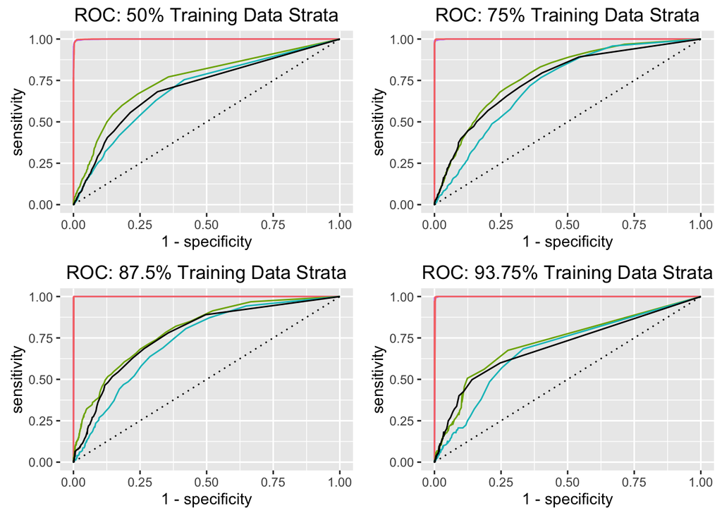

```r
grid.arrange(g.rf.1, g.rf.2, g.rf.3, g.rf.4, ncol = 2, nrow = 2)
```

# Box and whisker plots

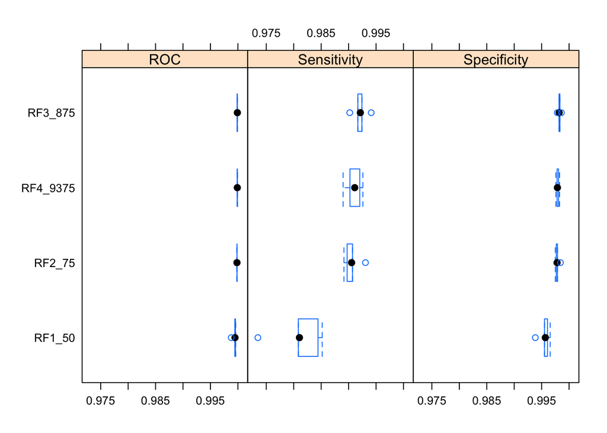

```r
bwplot(resamples(list(RF1_50 = fit_rf1, RF2_75 = fit_rf2, RF3_875 = fit_rf3,
    RF4_9375 = fit_rf4)), metric = c("ROC", "Specificity", "Sensitivity"))
```

# Performance Summaries

Below is a summary of the performance characteristics of each trained model

```r
strata <- c(1/2, 3/4, 7/8, 15/16)
folds <- c(5, 5, 5, 5)
repeats <- c(1, 1, 1, 1)
accuracies <- c(c.acc.1, c.acc.2, c.acc.3, c.acc.4)
oob <- c(ooe.1, ooe.2, ooe.3, ooe.4)
acc <- data.frame(Strata = strata, Accuracy = accuracies, OOB = oob)
print.xtable(xtable(acc), type = "html")
```

|  | Strata | Accuracy | OOB |
| --- | --- | --- | --- |
| 1 | 0.50 | 0.98 | 0.01 |
| 2 | 0.75 | 0.99 | 0.01 |
| 3 | 0.88 | 1.00 | 0.00 |
| 4 | 0.94 | 1.00 | 0.01 |